# What do you mean?

Today, we will go over the answers to assignment 01 🎈.

If you have been granted an extension to the assignment, please do not view this lecture until your assignment is submitted. Feel free to return at 1PM to re-join the session after answers are discussed.

# 1. Doing Data Science Mentally

```r
library(tidyverse)
sales = read_csv("../data/sales.csv")
```

Let’s get you thinking about conditional probabilities.. To do this, read in the `sales.csv` data. If listing is:

These can all be done easily with `filter()` and `group_by`.

## 1.1

in 1999, what’s your best guess as to the price of that house? *My best guess is the mean price in this group:*

```r
sales %>% filter(year == 1999) %>% summarize(mean(price))
```

```
## # A tibble: 1 x 1
##   `mean(price)`
##           <dbl>
## 1        90080.
```

## 1.2

a *detached house* in 1999, what’s your best guess as to the price of that house? *My best guess is the mean price in this group:*

```r
sales %>% filter(year == 1999 & property_type == "detached") %>%
  summarize(mean(price))
```

```
## # A tibble: 1 x 1
##   `mean(price)`
##           <dbl>
## 1       141262.
```

## 1.3

a flat, is it likely to be sold as a freehold or leasehold? *A leasehold, since that is the most common type of flat.*

```r
sales %>% filter(property_type=="flat") %>%
  group_by(is_freehold) %>% summarize(count = n()) %>%
  mutate(percent = round(count / sum(count), 2))
```

```
## # A tibble: 2 x 3
##   is_freehold count percent
##   <lgl>       <int>   <dbl>
## 1 FALSE       73408    0.97
## 2 TRUE         1929    0.03
```

## 1.4

a detached house, is it likely to be sold as a freehold or leasehold? *A freehold, since that is the most common type of detached listing.*

```r
sales %>% filter(property_type=="detached") %>%
  group_by(is_freehold) %>% summarize(count = n())%>%
  mutate(percent = round(count / sum(count), 2))
```

```
## # A tibble: 2 x 3
##   is_freehold count percent
##   <lgl>       <int>   <dbl>
## 1 FALSE         997    0.02
## 2 TRUE        51042    0.98
```

```r
sales %>%
  group_by(property_type, is_freehold) %>% summarize(count = n())%>%
  mutate(percent = round(count / sum(count), 2))
```

```
## # A tibble: 8 x 4
## # Groups:   property_type [4]
##   property_type is_freehold  count percent
##   <chr>         <lgl>        <int>   <dbl>
## 1 detached      FALSE          997    0.02
## 2 detached      TRUE         51042    0.98
## 3 flat          FALSE        73408    0.97
## 4 flat          TRUE          1929    0.03
## 5 semidetached  FALSE         5155    0.06
## 6 semidetached  TRUE         82892    0.94
## 7 terraced      FALSE        11725    0.09
## 8 terraced      TRUE        123743    0.91
```

## 1.5

for more than 500000, is it likely to be sold as a freehold or leasehold? *A freehold, since that is the most common kind of expensive listing.*

```r
sales %>% filter(price > 500000) %>%
  group_by(is_freehold) %>% summarize(count = n()) %>%
  mutate(percent = round(count / sum(count), 2))
```

```
## # A tibble: 2 x 3
##   is_freehold count percent
##   <lgl>       <int>   <dbl>
## 1 FALSE        1050    0.12
## 2 TRUE         7780    0.88
```

# 2. A Linear Model

Fit a linear model that predicts listing price using a unique mean in each year. Interpreting this model:

Be careful! In this model, are `years` numbers or categories?

```r
yearly_price_model = lm(price ~ 0 + as.factor(year), data=sales)
broom::tidy(yearly_price_model)
```

```
## # A tibble: 23 x 5
##    term                estimate std.error statistic  p.value
##    <chr>                  <dbl>     <dbl>     <dbl>    <dbl>
##  1 as.factor(year)1995   70288.     5425.      13.0 2.22e-38
##  2 as.factor(year)1996   67324.      998.      67.5 0.
##  3 as.factor(year)1997   72745.      891.      81.6 0.
##  4 as.factor(year)1998   79685.      888.      89.7 0.
##  5 as.factor(year)1999   90080.      838.     107.  0.
##  6 as.factor(year)2000  105884.      906.     117.  0.
##  7 as.factor(year)2001  121864.      852.     143.  0.
##  8 as.factor(year)2002  147174.      847.     174.  0.
##  9 as.factor(year)2003  167743.      895.     187.  0.
## 10 as.factor(year)2004  184307.      869.     212.  0.
## # … with 13 more rows
```

## 2.2

What’s the model’s prediction of listing price in 1999? How does this compare to your guess from section 1? *The prediction is the same as the average I computed above. This is because the model is a **conditional model**, and predicts the price given the observations within that year. This is because factors are encoded as one-hot encoding, and only observations within the factor level are considered when estimating that effect.*

```r
scenario = data.frame(year = "1999")
predict(yearly_price_model, scenario)
```

```
##        1
## 90080.24
```

## 2.3

There are three things I would keep in mind here. First, recall that you can use the `residuals(model)` function to extract your model prediction errors and you can also get predictions using `predict(model)`. Second, you may find it useful to create columns containing model predictions or errors. Finally, remember the typical issues that models can have, such as heteroskedasticity or bias when predictions are grouped in a way the model ignores.

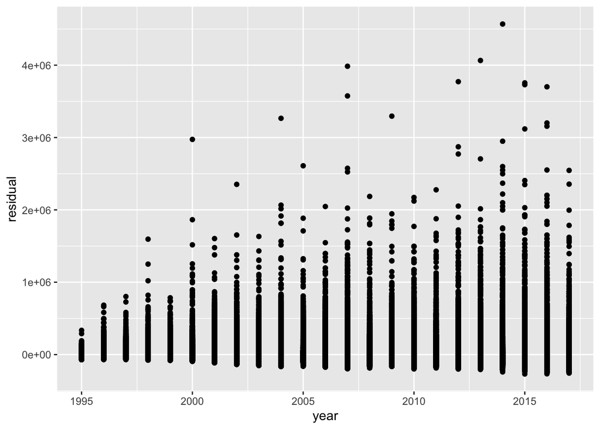

```r
sales %>% mutate(residual = residuals(yearly_price_model), fit = fitted.values(yearly_price_model)) %>%
  ggplot(aes(x=year, group=year, y=residual)) + geom_point()
```

*The driving issue is that the actual variance of sales prices increases each year. We’re only using the years to allow the mean to change each year, but the model still assumes that each years’ variance is the same. This is means our model has **heteroskedastic errors**, and suggests that the confidence intervals for our estimates will be off.*

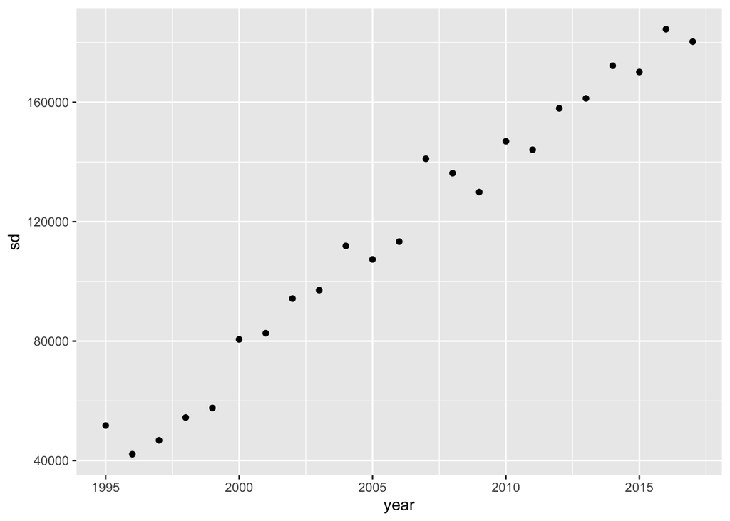

```r
sales %>% group_by(year) %>% summarize(sd = sd(price)) %>%
     ggplot(aes(x=year, y=sd)) + geom_point()
```

*This is somewhat resolved if we consider a variance-stabilizing transformation of the data, such as the log transform:*

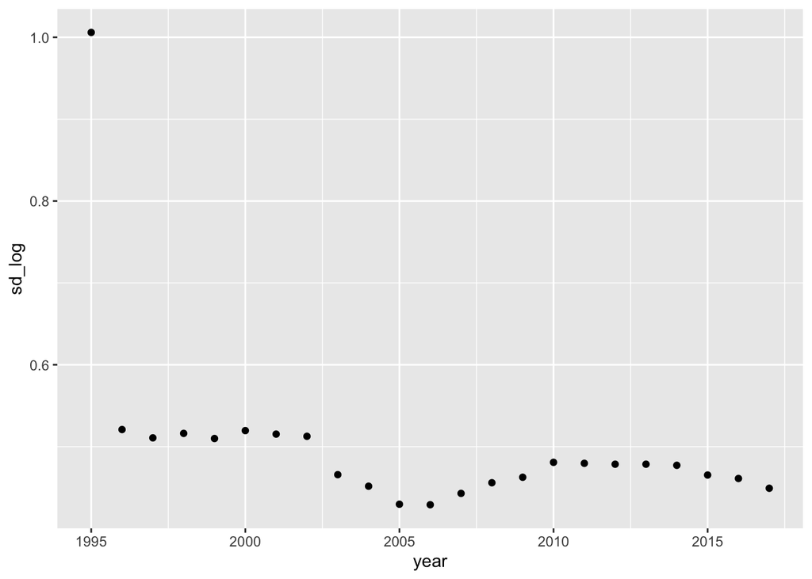

```r
sales %>% group_by(year) %>% summarize(sd_log = sd(log(price))) %>%
      ggplot(aes(x=year, y=sd_log)) + geom_point()
```

*Moving to bias, the model has a “fixed effect” in each year, so it is unbiased when predicting the year’s observations. Thus, on average, the errors cancel out within each year:*

```r
sales %>% mutate(residual = residuals(yearly_price_model)) %>% group_by(year) %>% summarize(mean(residual))
```

```
## # A tibble: 23 x 2
##     year `mean(residual)`
##    <dbl>            <dbl>
##  1  1995         1.38e-12
##  2  1996         2.11e-12
##  3  1997        -4.27e-13
##  4  1998        -7.00e-14
##  5  1999         7.18e-13
##  6  2000         5.05e-12
##  7  2001         1.45e-12
##  8  2002        -4.24e-12
##  9  2003         1.36e-11
## 10  2004        -4.26e-13
## # … with 13 more rows
```

*However, this unbiasedness does not extend to other kinds of groupings. For example, our model severely under-predicts detached house prices, but substantially over-predicts flats and terraced house prices.*

```r
sales %>% mutate(residual = residuals(yearly_price_model)) %>% group_by(property_type) %>% summarize(mean(residual))
```

```
## # A tibble: 4 x 2
##   property_type `mean(residual)`
##   <chr>                    <dbl>
## 1 detached                97605.
## 2 flat                   -34589.
## 3 semidetached             -201.
## 4 terraced               -18128.
```

*Further, we can even use a t-test to express how “significant” this mis-prediction is, relative to an unbiased prediction which would have a mean of zero. `t_stat` values beyond 2 would indicate significant bias.*

```r
sales %>% mutate(residual = residuals(yearly_price_model)) %>% group_by(property_type) %>% summarize(mean = mean(residual), sd = sd(residual), count=n()) %>% mutate(t_stat = mean/(sd/sqrt(count)))
```

```
## # A tibble: 4 x 5
##   property_type    mean      sd  count   t_stat
##   <chr>           <dbl>   <dbl>  <int>    <dbl>
## 1 detached       97605. 169443.  52039  131.
## 2 flat          -34589.  86910.  75337 -109.
## 3 semidetached    -201. 104110.  88047   -0.574
## 4 terraced      -18128. 103592. 135468  -64.4
```

# 3. Getting Nonlinear

## 3.1

Fit a *generalized* linear model that predicts whether a listing is a freehold using the price of the listing. *Remember, this is linear in the log odds… or, explained: “linear” part of the model predicts a latent normal variable governing how “likely” the observation is a freehold. If we think of $y_i$ as indicating whether the observation is a freehold or not, then we might say that the probability $y_i$ is a freehold is some value $\pi_i$. When this probability is greater than some threshold $t$, then $y_i = 1$ (spelled in math as $y_i = 1 | \pi_i > t$). The logistic model focuses on modelling the log of the odds, spelled below*:
$$\log\left(\frac{\pi_i}{1 - \pi_i}\right) = \alpha + x_{i1}\beta_1 + x_{i2}\beta_2 + ...$$
*That left hand side is the log odds of $i$ being freehold, and the right hand side is the “linear” part of the model. When the probability $\pi_i$ is big, the log odd are positive. When the probability is small, the log odds are negative. The log odds work well because they convert probabilities (which only exist as values between 0 and 1) into values that can exist across the whole number line.*

```r
freehold_model = glm(is_freehold ~ price,
                     data=sales,
                     family=binomial())
```

## 3.2

According to the model, do more expensive listings tend to be freehold properties? *Yes, the price is statistically significant predictor for whether something is a freehold listing.*

```r
broom::tidy(freehold_model)
```

```
## # A tibble: 2 x 5
##   term          estimate    std.error statistic p.value
##   <chr>            <dbl>        <dbl>     <dbl>   <dbl>
## 1 (Intercept) 0.747      0.00691          108.        0
## 2 price       0.00000176 0.0000000353      49.8       0
```

*To improve upon this, use the `predict` function to get probabilities back for model observations. That is, moving from a price of £100k to a price of £200k, the probability of being a freehold listing goes from 71% to 74%.*

```r
predict(freehold_model, data.frame(price=c(100000,200000)), type='response')
```

```
##         1         2
## 0.7156449 0.7499890
```

## 3.3

Remember: the prediction for a logistic model is a *logit* value by default. Set the `type` option to `"response"` in the `predict` function to get predicted *probabilities*.

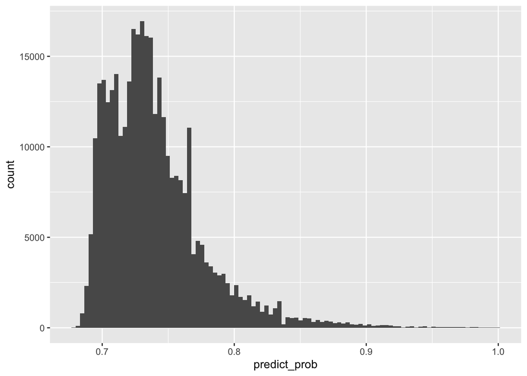

```r
sales %>% mutate(predict_prob = predict(freehold_model, type='response')) %>%
  ggplot(aes(x=predict_prob)) + geom_histogram(bins=100)
```

## 3.4

The tidy version is a bit of a monster, and issues with cross-tabs are a [common critique of the tidyverse](https://github.com/matloff/TidyverseSkeptic). This also uses a “retired” verb, `spread`, which is kind of like a simpler version of `pivot_wider`. Anyway, not recommended: `sales %>% mutate(pred_freehold = predict(freehold_model, type='response')>.5) %>%` `group_by(is_freehold, pred_freehold) %>%` `summarize(n=n()) %>%` `spread(is_freehold, n)` 🤮

```r
lax = with(sales %>% mutate(predict_prob = predict(freehold_model, type='response')),
     table(actual = is_freehold,
           predicted = predict_prob > .5))
lax
```

```
##        predicted
## actual    TRUE
##   FALSE  91285
##   TRUE  259606
```

- $\hat{p}>.75$ means a house is a freehold.

```r
medium= with(sales %>% mutate(predict_prob = predict(freehold_model, type='response')),
     table(actual = is_freehold, predicted = predict_prob > .75))
```

- $\hat{p}>.99$ means a house is a freehold.

```r
strict = with(sales %>% mutate(predict_prob = predict(freehold_model, type='response')),
     table(actual = is_freehold, predicted = predict_prob > .99))
strict
```

```
##        predicted
## actual   FALSE   TRUE
##   FALSE  91282      3
##   TRUE  259554     52
```

## 3.5

*You can see the whole accuracy curve, too, if you’re interested in finding the absolute best value for the cutoff. Using a cutoff around .68, you can get some pretty good accuracy. To the left of that, you probably classify all observations as one class and, as the threshold goes to 1, you probably classify all the observations into the other class.*

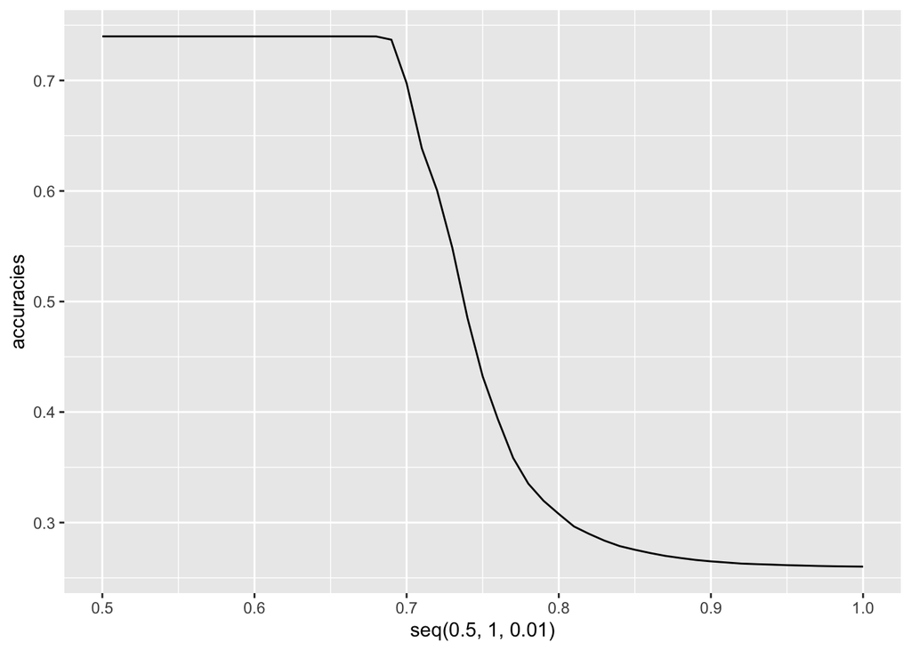

```r
accuracy = function(threshold,
                    percent=TRUE,
                    data=sales, model=freehold_model){
  n_right = data %>% mutate(predict_prob = predict(model, type='response')) %>%
                     mutate(predict_binary = predict_prob > threshold) %>%
                     transmute(agreement = predict_binary == is_freehold) %>%
                     summarize(n_right = sum(agreement)) %>% pull(n_right)
  return(ifelse(percent,
                n_right/nrow(data),
                n_right))
}


accuracies = c();

for(t in seq(.5, 1, .01)){
  accuracies <- c(accuracies, accuracy(t))
}
qplot(seq(.5, 1, .01), accuracies, geom = 'line')
```

# 4. Thinking through what all this means

## 4.1

Go back to your analyses in part 1.4. What percentage of the other house types are freehold or leasehold? Is there an issue with confounding in your model from section 3? *YES, there is totally confounding of the model from section 3. You can see for yourself: whether or not a property is freehold basically boils down to whether a property is a flat:*

```r
sales %>% group_by(property_type) %>%
  summarize(pct_freehold = mean(is_freehold))
```

```
## # A tibble: 4 x 2
##   property_type pct_freehold
##   <chr>                <dbl>
## 1 detached            0.981
## 2 flat                0.0256
## 3 semidetached        0.941
## 4 terraced            0.913
```

*Basically no flats are freehold, so if the listing is a flat, you know it’s not a freehold.*

## 4.1

```r
freehold_plus = glm(is_freehold ~ 1 + property_type + price, data=sales, family=binomial())
broom::tidy(freehold_plus)
```

```
## # A tibble: 5 x 5
##   term                           estimate    std.error statistic   p.value
##   <chr>                             <dbl>        <dbl>     <dbl>     <dbl>
## 1 (Intercept)                3.96         0.0355          112.   0.
## 2 property_typeflat         -7.59         0.0400         -190.   0.
## 3 property_typesemidetached -1.17         0.0355          -32.9  2.53e-237
## 4 property_typeterraced     -1.59         0.0340          -46.7  0.
## 5 price                     -0.0000000909 0.0000000565     -1.61 1.08e-  1
```

*This makes sense, when you think about the social economy of housing and tenancy. Flats, which are often one floor (if that) of a terraced house, are generally put up for sale by the building owner as a leased property. However, detached houses are large, independent structures. They’re generally bought and sold as a whole, with full rights given to the buyer. So long as we control for the type of property, the price of a property generally won’t have a significant effect on the tenancy type.*